# STA 601/360 Homework8

Jae Hyun Lee, jl914

06 November, 2019

# HW8 for STA-601

## Exercise 1

#### a)

Run gibbs sampling to approximate the posterior distribution of {$\theta, \sigma^2, \mu, \tau^2$}. Assess the convergence of Markov chain and find the efective sample size for {$\sigma^2, \mu, \tau^2$}.

The full conditional distribution of parameters are as below:
$$\begin{aligned}
\mu|\theta_1,\ldots,\theta_m,\tau^2 &\sim N\left(
\frac{\sum_{i=1}^m \theta_i/\tau^2 + \mu_0/\gamma_0^2}{m/\tau^2 + 1/\gamma_0^2},
\frac{1}{m/\tau^2 + 1/\gamma_0^2}
\right), \\
1/\tau^2|\theta_1,\ldots,\theta_m,\mu_0 &\sim Gamma\left(
\frac{\eta_0 + m}{2},
\frac{\eta_0\tau_0^2 + \sum_{i=1}^m (\theta_i - \mu)^2}{2}
\right),
\end{aligned}$$

$$\begin{aligned}
\theta_j|y_{1j},\ldots,y_{n_j,j},\sigma^2&\sim N\left(
\frac{\sum_{i=1}^{n_j} y_{ij}/\sigma^2 + \mu/\tau^2}{n_j/\sigma^2 + 1/\tau^2},
\frac{1}{n_j/\sigma^2 + 1/\tau^2}
\right), \\
\sigma^2|y_{11},\ldots,y_{n_m,m},\theta_1,\ldots,\theta_m &\sim Gamma\left(
\frac{\nu_0 + \sum_{j=1}^m n_j}{2},
\frac{\nu_0\sigma_0^2 + \sum_{j=1}^{m} \sum_{i=1}^{n_j}(y_{ij}-\theta_j)^2}{2}
\right).
\end{aligned}$$

```r
baseurl <- "http://www2.stat.duke.edu/~pdh10/FCBS/Exercises/"
school <- list()
for(i in 1:8){
  temp <- read.table(paste(baseurl,"school",i,".dat",sep = ""), header = F)
  school[[i]] <- temp
}
```

```r
prior <- list(mu = c(mu0 = 7, gamma0 = 5),
              tau = c(eta0 = 2, tau0 = 10),
              sigma = c(nu0 = 2, sigma0 = 15))
```

```r
gibbs_Q1 <- function(data, prior, iteration){
  mu0 <- prior$mu[1]; gamma0 <- prior$mu[2]
  eta0 <- prior$tau[1]; tau0 <- prior$tau[2]
  nu0 <- prior$sigma[1]; sigma0 <- prior$sigma[2]

  theta_cur <- rep(0,8); sigma_cur <- 1; mu_cur <- 0; tau_cur <- 1
  theta <- data.frame(matrix(rep(NA, iteration*8), ncol = 8))
  mu <- rep(NA, iteration); tau <- rep(NA, iteration)
  sigma <- rep(NA, iteration)

  ybar <- sapply(flatten(data),mean)
  ynum <- sapply(flatten(data),length)
  for(i in 1:iteration){
    #update theta
    theta_var <- (tau_cur^(-1) + ynum*sigma_cur^(-1))^(-1)
    theta_mean <- (theta_var * (tau_cur^(-1)*mu_cur + sigma_cur^(-1)*ynum*ybar))
    theta_cur <- theta[i,] <- rnorm(8,mean = theta_mean, sd = theta_var^(1/2))

    #update mu
    mu_var <- (gamma0^(-1) + 8*tau_cur^(-1))^(-1)
    mu_mean <- mu_var * (mu0 * gamma0^(-1) + 8*mean(theta_cur)*tau_cur^(-1))
    mu_cur <- mu[i] <- rnorm(1, mean = mu_mean, sd = mu_var^(1/2))

    #update tau
    eta <- eta0 + 8
    taun <- tau0*eta0 + sum((theta_cur - mu_cur)^2)
    tau_cur <- tau[i] <- rgamma(1, eta/2, taun/2)^(-1)

    #update sigma
    nu <- nu0 + sum(ynum)
    SSE <- 0
    for(j in 1:8){
      temp <- sum((data[[j]]-theta_cur[j])^2)
      SSE <- SSE + temp
    }
    sigman <- nu0 * sigma0 + SSE
    sigma_cur <- sigma[i] <- rgamma(1, nu/2, sigman/2)^(-1)
  }
  result <- list(theta = theta,
                 sigma = sigma,
                 mu = mu,
                 tau = tau)
  return(result)
}
sample_Q1 <- gibbs_Q1(data = school, prior = prior, iteration = 10000)
```

```r
par(mfrow = c(1,3))
post_samples <- sample_Q1[c("sigma","mu","tau")]
sapply(post_samples,effectiveSize)
```

```
## sigma.var1    mu.var1   tau.var1
##   9314.483   7995.647   8400.584
```

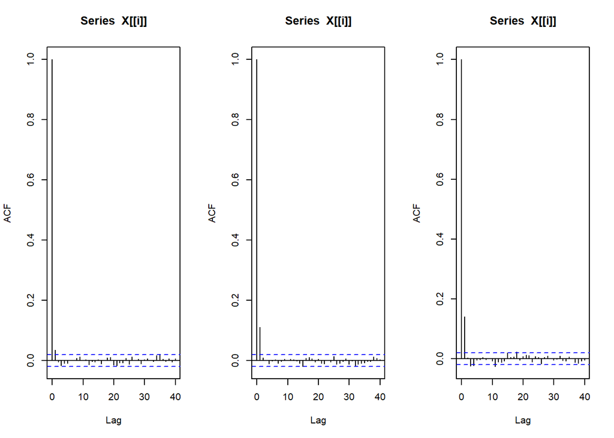

```
##        sigma         mu            tau
## acf    Numeric,41    Numeric,41    Numeric,41
## type   "correlation" "correlation" "correlation"
## n.used 10000         10000         10000
## lag    Numeric,41    Numeric,41    Numeric,41
## series "X[[i]]"      "X[[i]]"      "X[[i]]"
## snames NULL          NULL          NULL
```

```r
sapply(post_samples,acf)
```

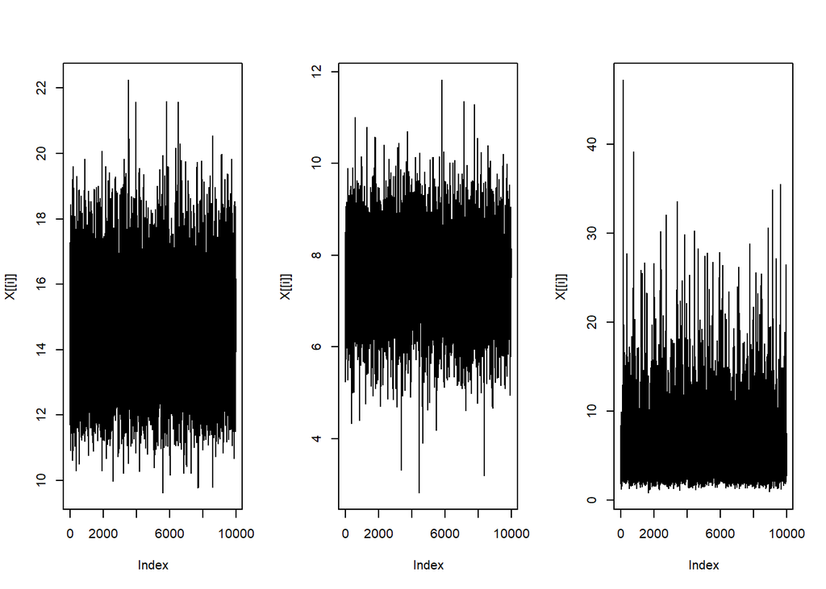

```r
sapply(post_samples,plot,type = "l")
```

#### b)

Compute the posterior means and 95% confidence interval for {$\sigma^2, \mu, \tau$}. And compare the posterior distribution to prior distribution.

```r
confidence <- function(x){
  bound <- c(quantile(x,0.025),quantile(x,0.975))
  return(bound)
}

prior_samples <- list(sigma = rgamma(10000,1,15)^(-1),
                      mu = rnorm(10000, 7, 5^(1/2)),
                      tau = rgamma(10000,1,10)^(-1))

kable(sapply(post_samples, mean), caption = "posterior mean")
```

posterior mean

|  | x |
| --- | --- |
| sigma | 14.467724 |
| mu | 7.565714 |
| tau | 5.549085 |

```r
kable(sapply(post_samples, confidence), caption = "confidence region")
```

confidence region

|  | sigma | mu | tau |
| --- | --- | --- | --- |
| 2.5% | 11.73184 | 5.885546 | 1.937275 |
| 97.5% | 17.80265 | 9.169730 | 14.121681 |

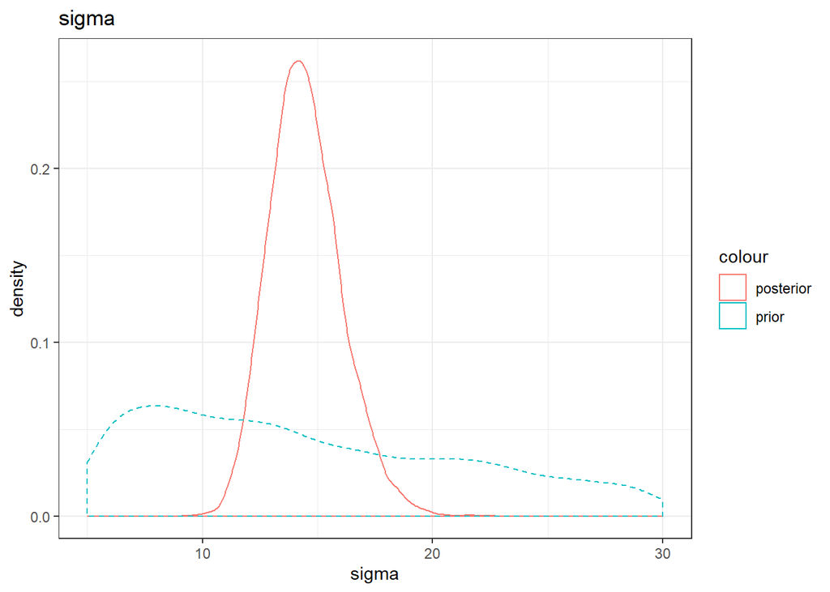

```r
post_samples <- bind_cols(post_samples)
prior_samples <- bind_cols(prior_samples)

p1 <- ggplot(data = post_samples, aes(x = sigma, col = "posterior"))+
  geom_density() +
  xlim(5,30) +
  geom_density(aes(x = prior_samples$sigma, col = "prior"), linetype = 2) +
  labs(title = "sigma")

p2 <- ggplot(data = post_samples, aes(x = mu, col = "posterior"))+
  geom_density() +
  xlim(0,20) +
  geom_density(aes(x = prior_samples$mu, col = "prior"), linetype = 2)+
  labs(title = "mu")

p3 <- ggplot(data = post_samples, aes(x = tau, col = "posterior"))+
  geom_density() +
  xlim(0,20) +
  geom_density(aes(x = prior_samples$tau, col = "prior"), linetype =2)+
  labs(title = "tau")
p1
```

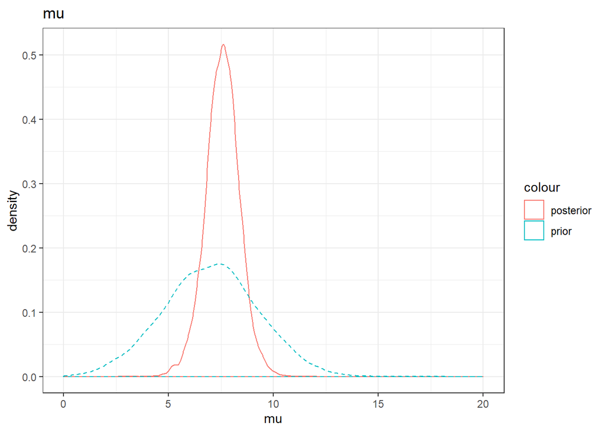

```r
p2
```

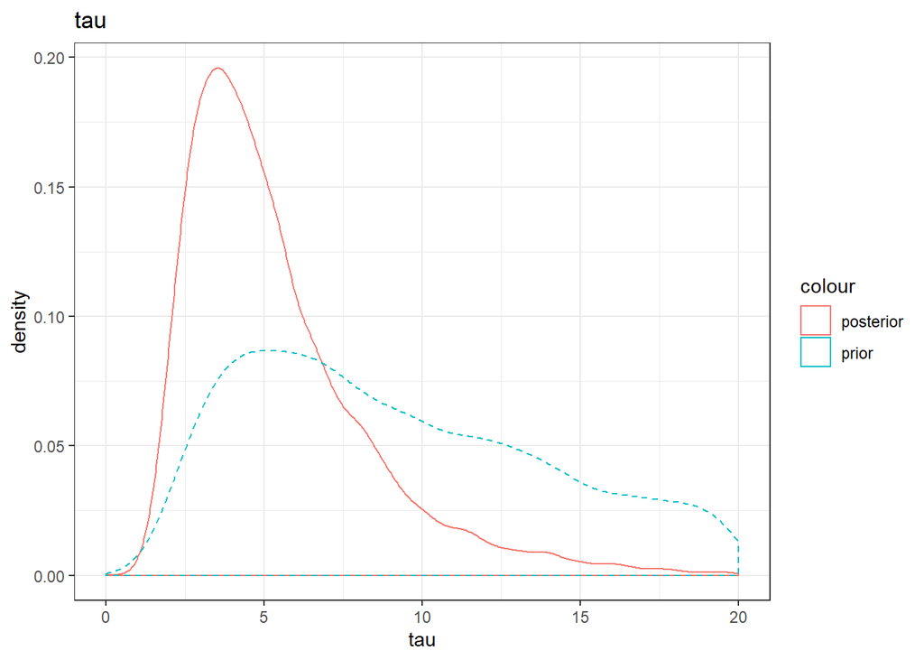

```r
p3
```

#### c)

Plot the posterior density of R and compare it of the prior density of R

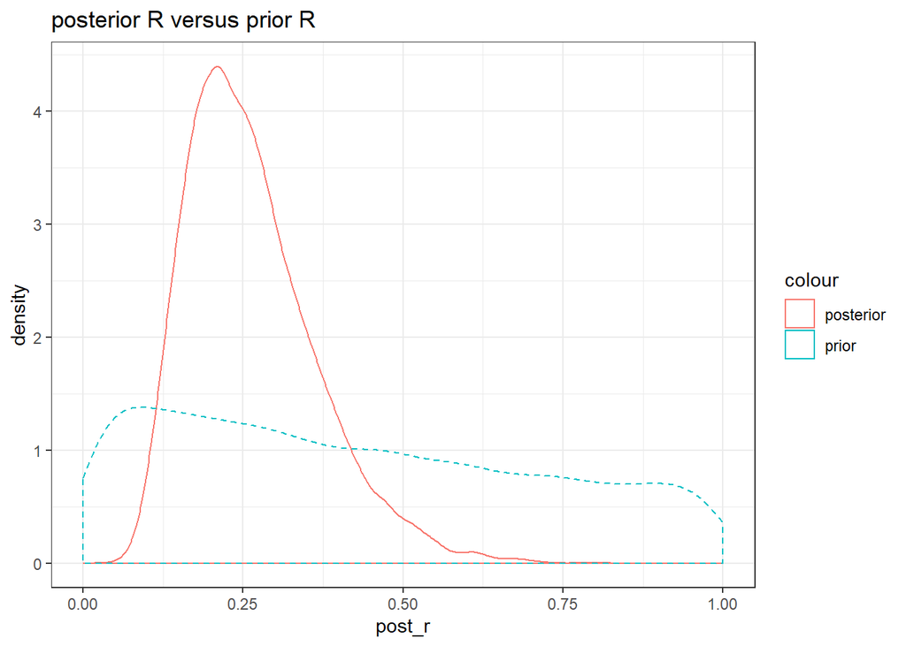

```r
post_r <- post_samples$tau/(post_samples$tau + post_samples$sigma)
prior_r <- prior_samples$tau/(prior_samples$tau + prior_samples$sigma)
ggplot() +
  geom_density(aes(x = post_r, col = "posterior")) +
  geom_density(aes(x = prior_r, col = "prior"), linetype = 2) +
  labs(title = "posterior R versus prior R")
```

R indicates the contribution of between-school variance in total variance. Our prior R is so diffused. On the other hand, posterior R is concentrated at 0.25 which indicates smaller contribution of between-school variance to total variance.

#### d)

Obtain the posterior probability that $\theta_7$ is smaller than $\theta_6$ as well as the posterior probability that $\theta_7$ is smaller than other $\theta's$

```r
post_theta <- sample_Q1$theta
mean(post_theta$X7<post_theta$X6)
```

```
## [1] 0.5266
```

```r
mean(apply(post_theta,1 , min) == post_theta$X7)
```

```
## [1] 0.326
```

#### e)

Plot the sample average against the posterior expectation and describe relationship. Add sample mean of all observations and compare it to the posterior mean.

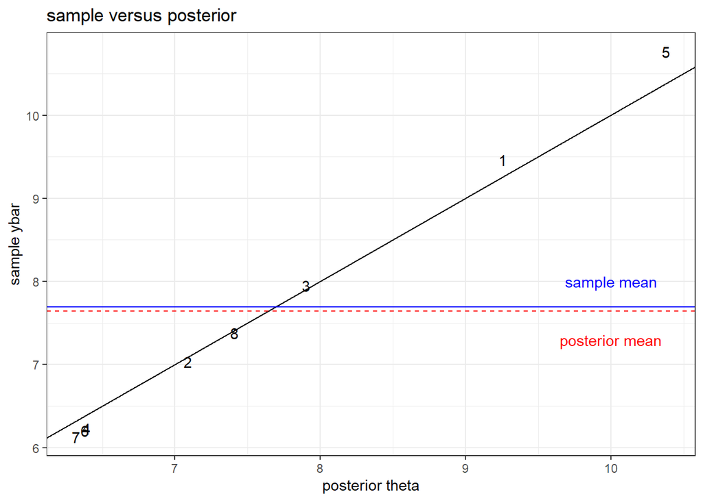

```r
ybar <- sapply(flatten(school), mean)
post_mean <- apply(post_theta,2,mean)
overall_sample_mean <- mean(unlist(school))
overall_post_mean <- mean(unlist(post_theta))
ggplot(mapping = aes(x = post_mean, y = ybar)) +
  geom_text(label = 1:8) +
  geom_abline(slope = 1) +
  geom_hline(yintercept = overall_post_mean, linetype = 2, col = "red") +
  geom_hline(yintercept = overall_sample_mean, linetype = 1, col = "blue") +
  annotate("text",x = 10, y = 8, label = "sample mean", col = "blue") +
  annotate("text",x = 10, y = 7.3, label = "posterior mean", col = "red") +
  labs(title = "sample versus posterior", x = "posterior theta", y = "sample ybar")
```

The posterior mean for parameter $\mu$ which is parameter of overall mean is a little less than total sample average. This might be caused by prior information which assumed smaller value for $\mu$ than sample has. For the relationship of sample mean and posterior mean for each group, they seem to be shrunk to global mean when considering their comparing the line y = x.

## Exercise2

```r
swim <- read.table("http://www2.stat.duke.edu/~pdh10/FCBS/Exercises/swim.dat")
swim <- cbind.data.frame(t(swim),week = seq(2,12,2))
colnames(swim) <- c("p1","p2","p3","p4","week")
```

#### a)

Fit a linear regression model of swimming time as the response and week as the explantory variable. competitive times range from 22 to 24. Since it ranges from 22 to 24, I set up prior b0 as (23,-0.1) because as week passed, I assume that player might improve their ability. For the prior of variance, I assume that average variance would be 0.25 so that 95% players are capture in interval.

$\rightarrow P(y \in (22,24)) = 0.95$

$P(\beta) \sim N(b_o,\Sigma_\beta)$ where $b_0 = \begin{bmatrix} 23 \\ -0.1\end{bmatrix}, \Sigma_\beta = \begin{bmatrix} 1 & 0 \\ 0 & 0.1 \end{bmatrix}$ $P(1/\sigma^2) \sim gamma(\nu_0/2,\nu_0\sigma_0^2/2)$ where $\nu_0 = 4, \sigma_0^2 = 0.25$

For the full conditional distribution for $\beta, 1/\sigma^2$ are as below :

$$\boldsymbol{\beta}|\mathbf{y},\mathbf{X},\sigma^2 \sim N(
(\Sigma_0 + \mathbf{X}^T\mathbf{X}/\sigma^2)^{-1}(\Sigma_0^{-1}\boldsymbol{\mu} + \mathbf{X}^T\mathbf{y}/\sigma^2),
(\Sigma_0 + \mathbf{X}^T\mathbf{X}/\sigma^2)^{-1})$$

$$1/\sigma^2|\mathbf{y},\mathbf{X},\boldsymbol{\beta} \sim Gamma(
(\nu_0 + n)/2,
[\nu_0\sigma_0^2 + (\mathbf{Y-X}\boldsymbol{\beta})^T(\mathbf{Y-X}\boldsymbol{\beta})]/2
).$$

```r
prior <- list(b0 = c(23, -0.1),
              sigma_beta0 = matrix(c(1,0,0,0.1), nrow = 2),
              nu0 = 4,
              sigma0 = 0.25)
gibbs_Q2 <- function(data, prior, iteration){
  #set up prior
  b0 <- prior$b0; sigma_beta0 <- prior$sigma_beta0
  nu0 <- prior$nu0; sigma0 <- prior$sigma0

  #set data
  pred.mat <- cbind(1,1:6)
  identity <- matrix(c(1,0,0,1), nrow = 2)
  beta_cur <- c(23,0); sigma_cur <- 1
  beta <- matrix(rep(NA,2*iteration),ncol = 2)
  sigma <- rep(NA,iteration)
  pred.y <- rep(NA,iteration)

  for(i in 1:iteration){
    #update beta
    sigma_betan <- solve((t(pred.mat) %*% pred.mat)/sigma_cur + solve(sigma_beta0))
    bn <- sigma_betan %*% ((t(pred.mat) %*% data)/sigma_cur + solve(sigma_beta0) %*% b0)
    beta_cur <- beta[i,] <- MASS::mvrnorm(n = 1, mu = bn, Sigma = sigma_betan)

    #update sigma
    nun <- nu0 + length(data)
    sigman <- nu0*sigma0 + t(data- pred.mat %*% beta_cur) %*% (data- pred.mat %*% beta_cur)
    sigma_cur <- sigma[i] <- rgamma(1, nun, sigman)^(-1)

    #predict y
    pred.y[i] <- c(1,14) %*% beta[i,] + rnorm(1,0,sigma[i]^(1/2))
  }

  result <- list(beta = beta,
                 sigma = sigma,
                 Y = pred.y)
  return(result)
}
p1 <- gibbs_Q2(swim$p1, prior, 10000)
p2 <- gibbs_Q2(swim$p2, prior, 10000)
p3 <- gibbs_Q2(swim$p3, prior, 10000)
p4 <- gibbs_Q2(swim$p4, prior, 10000)
mean(p1$Y); mean(p2$Y); mean(p3$Y); mean(p4$Y)
```

```
## [1] 22.01253
```

```
## [1] 23.9403
```

```
## [1] 23.02214
```

```
## [1] 23.10528
```

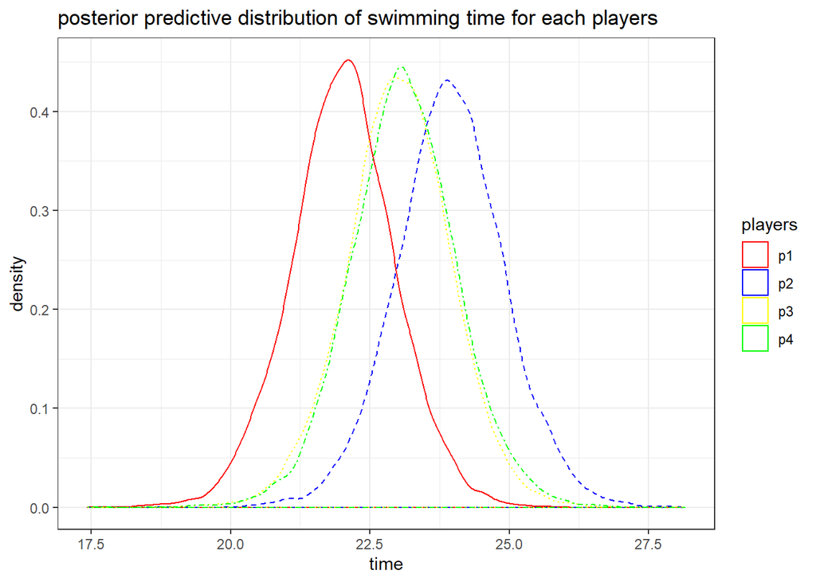

```r
ggplot() +
  geom_density(mapping = aes(x = p1$Y, group = 1, color = "LINE1"), linetype = 1) +
  geom_density(mapping = aes(x = p2$Y, group = 1, color = "LINE2"), linetype = 2) +
  geom_density(mapping = aes(x = p3$Y, group = 1, color = "LINE3"), linetype = 3) +
  geom_density(mapping = aes(x = p4$Y, group = 1, color = "LINE4"), linetype = 4) +
  labs(title = "posterior predictive distribution of swimming time for each players", x = "time",
       colors = "player") +
  scale_color_manual(values = c("red","blue","yellow","green"), labels = c("p1","p2","p3","p4"), name = "players")
```

#### b)

compute P($Y_j = max\{Y_1,Y_2,Y_3,Y_4 \mid Y\}$) for each swimmer j

```r
time <- cbind.data.frame(p1$Y,p2$Y,p3$Y,p4$Y)
time <- cbind.data.frame(time, apply(time,1,max))
colnames(time) <- c("p1","p2","p3","p4","max")
kable(apply(time[,-5], 2, function(x) mean(x == time[,5])), caption = "probability that each players place at last")
```

probability that each players place at last

|  | x |
| --- | --- |
| p1 | 0.0292 |
| p2 | 0.6047 |
| p3 | 0.1661 |
| p4 | 0.2000 |

When consider predictive posterior distribution of players and their probabilities that they place at last, player1 is very likely to be the most competitive player. Thus I recommend player1.

## Exercise 3

Derive the gibbs sampler for standard bayesian ANOVA

$$\begin{aligned}
&Y_{ijk} \sim N(\theta_ij,\sigma^2) \\
& where \; \theta_{ij} = \mu + a_i + b_j + ab_{ij}\\
& \mu \sim N(0, \sigma_\mu^2), \quad a_1 \cdot\cdot\cdot a_{m_1} \sim iid\; N(0, \sigma_a^2) \\
& b_1 \cdot\cdot\cdot b_{m_2} \sim iid \; N(0, \sigma_b^2), \quad ab_{11} \cdot\cdot\cdot ab_{m_1m_2} \sim iid \; N(0,\sigma^2_{ab})
\end{aligned}$$

Let overall observation number is $N$ and we can find that $\mathbf{a,b,ab}$ are $m_1, m_2, m_1 * m_2$ dimension. As a result, divided group has $m_1 * m_2$ and each group have $\frac{N}{m_1m_2}$

The likelihood function of data is as follow:
$$\begin{aligned}
P(Y \mid \boldsymbol{\theta}, \sigma^2) &\propto (\sigma^2)^{-N/2} exp\{-\frac{1}{2\sigma^2}\sum_i\sum_j\sum_k (y_{ijk} - \theta_{ij})^2 \} \\
= P(Y \mid \mathbf{a,b,ab}, \mu, \sigma^2) &\propto (\sigma^2)^{-N/2} exp\{-\frac{1}{2\sigma^2}\sum_i\sum_j\sum_k (y_{ijk} - \mu - a_i - b_j - ab_{ij})^2 \}
\end{aligned}$$
For full conditional distribution for $\mu$
$$\begin{aligned}
&P(Y \mid \mathbf{a,b,ab},\mu,\sigma^2) \propto_\mu exp\{-\frac{1}{2\sigma^2} (N\mu^2 -2\mu\sum_i\sum_j\sum_k (y_{ijk} - a_i - b_j - ab_{ij})) \} \\
&P(\mu \mid \mathbf{Y, a, b, ab}, \sigma^2) \propto P(\mu)P(Y \mid \mathbf{a,b,ab},\mu,\sigma^2) \\
&\propto exp\{-\frac{\mu^2}{2\sigma_\mu^2}\}exp\{-\frac{1}{2\sigma^2} (N\mu^2 -2\mu\sum_i\sum_j\sum_k (y_{ijk} - a_i - b_j - ab_{ij})) \} \\
&\rightarrow Var(\mu \mid \mathbf{Y, a, b, ab}, \sigma^2) = (\frac{N}{\sigma^2} + \frac{1}{\sigma^2_\mu})^{-1},
\quad E(\mu \mid \mathbf{Y, a, b, ab}, \sigma^2) = (\frac{N}{\sigma^2} + \frac{1}{\sigma^2_\mu})^{-1} \frac{\sum_i\sum_j\sum_k (y_{ijk} - a_i - b_j - ab_{ij})}{\sigma^2}
\end{aligned}$$
For full conditional distribution for $a_i$
$$\begin{aligned}
&P(Y \mid \mathbf{a,b,ab},\mu,\sigma^2) \propto_a exp\{-\frac{N}{2m_1\sigma^2} \sum_{i=1}^{m_1}(a_i^2 -2a_i\sum_j\sum_k (y_{ijk} - \mu - b_j - ab_{ij})) \} \\
&P(\mathbf{a} \mid \mathbf{Y, b, ab},\mu ,\sigma^2) \propto P(\mathbf{a})P(Y \mid \mathbf{a,b,ab},\mu,\sigma^2) \\
&\propto exp\{-\frac{1}{2\sigma_\mu^2}\sum_{i=1}^{m_1} a_i^2\}exp\{-\frac{N}{2m_1\sigma^2} \sum_{i=1}^{m_1}(a_i^2 -2a_i\sum_j\sum_k (y_{ijk} - \mu - b_j - ab_{ij})) \} \\
&=\prod_{i=1}^{m_1} P(a_i \mid \mathbf{Y, b, ab},\mu ,\sigma^2) \\
&\rightarrow P(a_i \mid \mathbf{Y, b, ab},\mu ,\sigma^2) = exp\{-\frac{1}{2\sigma_\mu^2} a_i^2\}exp\{-\frac{N}{2m_1\sigma^2} (a_i^2 -2a_i\sum_j\sum_k (y_{ijk} - \mu - b_j - ab_{ij})) \}\\
&\rightarrow Var(a_i \mid \mathbf{Y, b, ab}, \mu,\sigma^2) = (\frac{N}{m_1\sigma^2} + \frac{1}{\sigma^2_a})^{-1},
\quad E(a_i \mid \mathbf{Y, b, ab}, \mu,\sigma^2) = (\frac{N}{m_1\sigma^2} + \frac{1}{\sigma^2_a})^{-1} \frac{\sum_j\sum_k (y_{ijk} - \mu - b_j - ab_{ij})}{\sigma^2}
\end{aligned}$$
For full conditional distribution for $b_j$, similar with $a_i$
$$\begin{aligned}
Var(b_j \mid \mathbf{Y, a, ab}, \mu,\sigma^2) = (\frac{N}{m_2\sigma^2} + \frac{1}{\sigma^2_b})^{-1},
\quad E(b_j \mid \mathbf{Y, a, ab}, \mu,\sigma^2) = (\frac{N}{m_2\sigma^2} + \frac{1}{\sigma^2_a})^{-1} \frac{\sum_i\sum_k (y_{ijk} - \mu - a_i - ab_{ij})}{\sigma^2}
\end{aligned}$$
For full conditional distribution for $ab_{ij}$
$$\begin{aligned}
&P(Y \mid \mathbf{a,b,ab},\mu,\sigma^2) \propto_{ab} exp\{-\frac{N}{2m_1m_2\sigma^2} \sum_{i=1}^{m_1}\sum_{j=1}^{m_2}(ab_{ij}^2 -2ab_{ij}\sum_k (y_{ijk} - \mu - a_i - b_j)) \} \\
&P(\mathbf{ab} \mid \mathbf{Y, a, b},\mu ,\sigma^2) \propto P(\mathbf{ab})P(Y \mid \mathbf{a,b,ab},\mu,\sigma^2) \\
&\propto exp\{-\frac{1}{2\sigma_\mu^2}\sum_{i=1}^{m_1}\sum_{j=1}^{m_2}ab_{ij}^2\}exp\{-\frac{N}{2m_1m_2\sigma^2} \sum_{i=1}^{m_1}\sum_{j=1}^{m_2}(ab_{ij}^2 -2ab_{ij}\sum_k (y_{ijk} - \mu - a_i - b_j)) \} \\
&=\prod_{i=1}^{m_1}\prod_{j=1}^{m_2} P(ab_{ij} \mid \mathbf{Y, a, b},\mu ,\sigma^2) \\
&\rightarrow P(ab_{ij} \mid \mathbf{Y, a, b},\mu ,\sigma^2) = exp\{-\frac{1}{2\sigma_\mu^2}ab_{ij}^2\}exp\{-\frac{N}{2m_1m_2\sigma^2} (ab_{ij}^2 -2ab_{ij}\sum_k (y_{ijk} - \mu - a_i - b_j)) \}\\
&\rightarrow Var(ab_{ij} \mid \mathbf{Y, b, ab}, \mu,\sigma^2) = (\frac{N}{m_1m_2\sigma^2} + \frac{1}{\sigma^2_{ab}})^{-1},
\quad E(ab_{ij} \mid \mathbf{Y, a, b}, \mu,\sigma^2) = (\frac{N}{m_1m_2\sigma^2} + \frac{1}{\sigma^2_{ab}})^{-1} \frac{\sum_k (y_{ijk} - \mu - a_i - b_j )}{\sigma^2}
\end{aligned}$$
For semi-conjugate prior for variance of normal distribution, gamma distribution is appropriate choice
$$\begin{aligned}
&1/\sigma^2_\mu \sim gamma(\nu_\mu/2, \nu_\mu\tau_\mu^2/2) \\
&1/\sigma^2_a \sim gamma(\nu_a/2, \nu_a\tau_a^2/2) \\
&1/\sigma^2_b \sim gamma(\nu_b/2, \nu_\mu\tau_b^2/2) \\
&1/\sigma^2_{ab} \sim gamma(\nu_{ab}/2, \nu_\mu\tau_{ab}^2/2) \\
&1/\sigma^2 \sim gamma(\nu_0/2, \nu_0\tau_0^2/2)
\end{aligned}$$
As hierachical model, we can find that variance for $\mu, a, b, ab$ are not directly depending on data Y. When we update posterior distribution for variances
$$\begin{aligned}
&1/\sigma^2_\mu \sim gamma(\nu_\mu+1/2, (\nu_\mu\tau_\mu^2 + \mu^2)/2) \\
&1/\sigma^2_a \sim gamma(\nu_a + m_1/2, (\nu_a\tau_a^2+\sum^{m1}a_i^2)/2) \\
&1/\sigma^2_b \sim gamma(\nu_b + m2/2, (\nu_\mu\tau_b^2+\sum^{m2}b_i^2)/2) \\
&1/\sigma^2_{ab} \sim gamma((\nu_{ab}+m_1\times m_2)/2, (\nu_{ab}\tau_{ab}^2 +\sum^{m1}\sum^{m2}(ab_{ij})^2)/2) \\
&1/\sigma^2 \sim gamma(\nu_0 + N/2, (\nu_0\tau_0^2 + \sum_i\sum_j\sum_k(y_{ijk} - \mu - a_i - b_j -ab_{ij})^2)/2)
\end{aligned}$$

Applying above logic to data, we can specify that N = 60, m1 = 2, m2 = 3

```r
str(ToothGrowth)
```

```
## 'data.frame':    60 obs. of  3 variables:
##  $ len : num  4.2 11.5 7.3 5.8 6.4 10 11.2 11.2 5.2 7 ...
##  $ supp: Factor w/ 2 levels "OJ","VC": 2 2 2 2 2 2 2 2 2 2 ...
##  $ dose: num  0.5 0.5 0.5 0.5 0.5 0.5 0.5 0.5 0.5 0.5 ...
```

```r
ToothGrowth$dose <- as.factor(ToothGrowth$dose)
```

Arbitrary priors are selected because we don’t have any information about data. Priors for $\sigma^2$s are selected to satisfy weak information prior which have mean value 1

```r
prior <- list(mu = c(2,1),
              a = c(2,1),
              b = c(2,1),
              ab = c(2,1),
              sigma = c(2,1))
```

```r
data <- ToothGrowth
iteration = 10
i = 1
gibbs_Q3 <- function(data, prior, iteration){
  #set up prior
  m1 <- nlevels(data$supp); m2 <- nlevels(data$dose); N <- nrow(data)
  nu_mu <- prior$mu[1]; nu_a <- prior$a[1]; nu_b <- prior$b[1]; nu_ab <- prior$ab[1]; nu0 <- prior$sigma[1]
  tau_mu <- prior$mu[2]; tau_a <- prior$a[2]; tau_b <- prior$b[2]; tau_ab <- prior$ab[2]; tau0 <- prior$sigma[2]

  #set up
  mu_cur <- 0; a_cur <- rep(0,m1); b_cur <- rep(0,m2); ab_cur <- matrix(rep(0,m1*m2),ncol = 3)
  mu <- rep(NA,iteration); a <- data.frame(matrix(rep(NA,m1*iteration),ncol = m1)) %>% `colnames<-`(c("a1","a2"))
  b <- data.frame(matrix(rep(NA,m2*iteration), ncol = m2)) %>% `colnames<-`(c("b1","b2","b3"))
  ab <- array(rep(NA,m1*m2*iteration), dim = c(m1,m2,iteration))
  ab_vec <- data.frame(matrix(rep(NA,m1*m2*iteration),ncol = m1*m2)) %>% `colnames<-`(c("ab11","ab12","ab13","ab21","ab22","ab23"))

  ybar <- data %>%
      group_by(supp,dose) %>%
      dplyr::summarise(mean = mean(len))

  ynum <- data %>%
      group_by(supp,dose) %>%
      dplyr::summarise(count = n())
  ybar_a <- data %>% group_by(supp) %>% dplyr::summarise(sum = sum(len)) %>% select(sum)
  ybar_b <- data %>% group_by(dose) %>% dplyr::summarise(sum = sum(len)) %>% select(sum)
  #updating
  for(i in 1:iteration){
    data <- data %>%
      mutate(a_value = case_when(
        supp == "VC" ~ a_cur[1],
        supp == "OJ" ~ a_cur[2]
      )) %>%
      mutate(b_value = case_when(
        dose == 0.5 ~ b_cur[1],
        dose == 1 ~ b_cur[2],
        dose == 2 ~ b_cur[3]
      )) %>%
      mutate(ab_value = case_when(
        supp == "VC" & dose == 0.5 ~ ab_cur[1,1],
        supp == "VC" & dose == 1 ~ ab_cur[1,2],
        supp == "VC" & dose == 2 ~ ab_cur[1,3],
        supp == "OJ" & dose == 0.5 ~ ab_cur[2,1],
        supp == "OJ" & dose == 1 ~ ab_cur[2,2],
        supp == "OJ" & dose == 2 ~ ab_cur[2,3],
      ))

    #update sigma
    sigma_cur <- rgamma(1, (nu0 + N)/2,
                       (nu0*tau0 + sum((data$len - mu_cur - data$a_value - data$b_value - data$ab_value)^2)/2))^(-1)
    #update mu
    sigma_mu <- rgamma(1, (nu_mu+1)/2, (nu_mu*tau_mu + mu_cur^2)/2)^(-1)
    var_mu <- (N/sigma_cur + 1/sigma_mu)^(-1)
    E_mu <- var_mu*(sum(data$len) - N/m1*sum(a_cur) - N/m2*sum(b_cur) - N/(m1*m2)*sum(ab_cur))/sigma_cur
    mu_cur <- mu[i] <- rnorm(1, mean = E_mu, sd = var_mu^(1/2))

    #update a
    sigma_a <- rgamma(1, (nu_a + m1)/2, (nu_a*tau_a+sum(a_cur^2))/2)^(-1)
    var_a <- (N/(m1*sigma_cur) + 1/sigma_a)^(-1)
    E_a <- var_a * (ybar_a - (N*mu_cur)/m1 - N*mean(b_cur)/m1 - N/m1*apply(ab_cur,1,mean))/(sigma_cur*m1)
    a_cur <- a[i, ] <- rnorm(m1, mean = t(E_a), sd = var_a^(1/2))

    #update b
    sigma_b <- rgamma(1, (nu_b + m2)/2, (nu_b*tau_b+sum(b_cur^2))/2)^(-1)
    var_b <- (N/(m2*sigma_cur) + 1/sigma_b)^(-1)
    E_b <- var_b * (ybar_b - (N*mu_cur)/m2 - N*mean(a_cur)/m2 - N/m2*apply(ab_cur,2,mean))/(sigma_cur*m2)
    b_cur <- b[i, ] <- rnorm(m2, mean = t(E_b), sd = var_b^(1/2))

    #update ab
    sigma_ab <- rgamma(1, (nu_ab + m1*m2)/2, (nu_ab*tau_ab + sum(ab_cur^2))/2)^(-1)
    var_ab <- (N/(m1*m2*sigma_cur) + 1/sigma_ab) ^ (-1)
    E_ab <- var_ab * (ybar$mean * ynum$count - N/(m1*m2)*mu_cur - ynum$count*rep(a_cur,c(3,3)) - ynum$count*rep(b_cur,2))/(sigma_cur*m1*m2)
    ab_cur <- ab[,,i] <- matrix(rnorm(m1*m2, mean = E_ab, sd = var_ab^(1/2)),byrow = T,ncol = 3)
    ab_vec[i,] <- matrix(ab[,,i],nrow = 1)
  }

  result <- list(mu = mu,
                 a = a,
                 b = b,
                 ab = ab,
                 ab_vec = ab_vec)
  return(result)
}
sample_Q3 <- gibbs_Q3(data = ToothGrowth, prior = prior, iteration = 10000)
```

```r
sapply(sample_Q3[c("mu","a","b","ab_vec")],effectiveSize)
```

```
## $mu
##     var1
## 5100.837
##
## $a
##       a1       a2
## 6726.592 6578.402
##
## $b
##       b1       b2       b3
## 4618.702 8522.847 4348.591
##
## $ab_vec
##      ab11      ab12      ab13      ab21      ab22      ab23
##  8906.660  8579.132 10000.000 10000.000  8906.264  7893.011
```

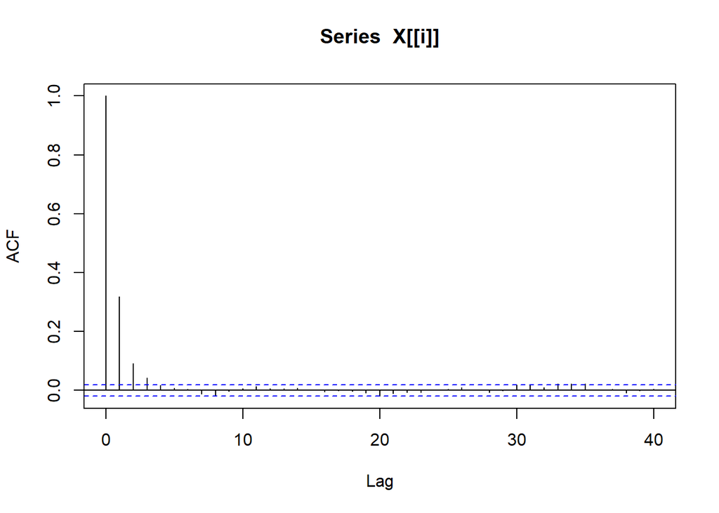

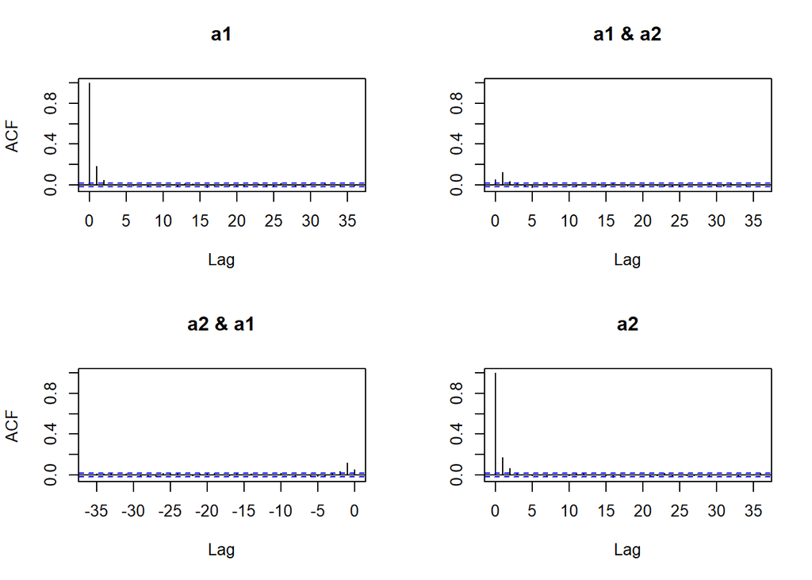

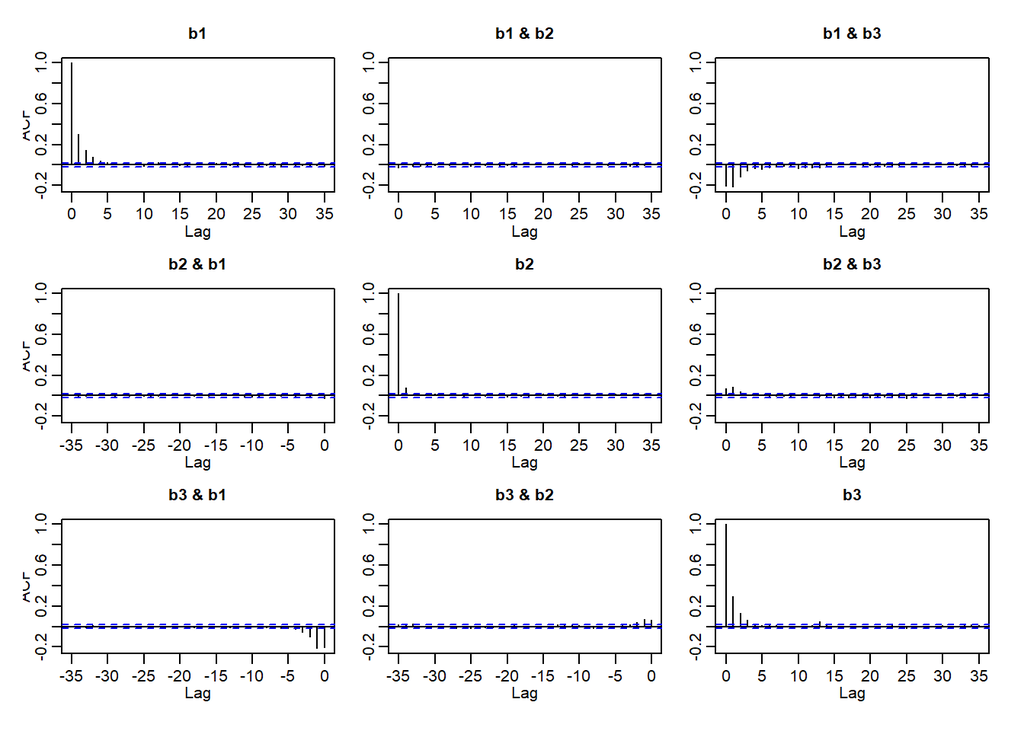

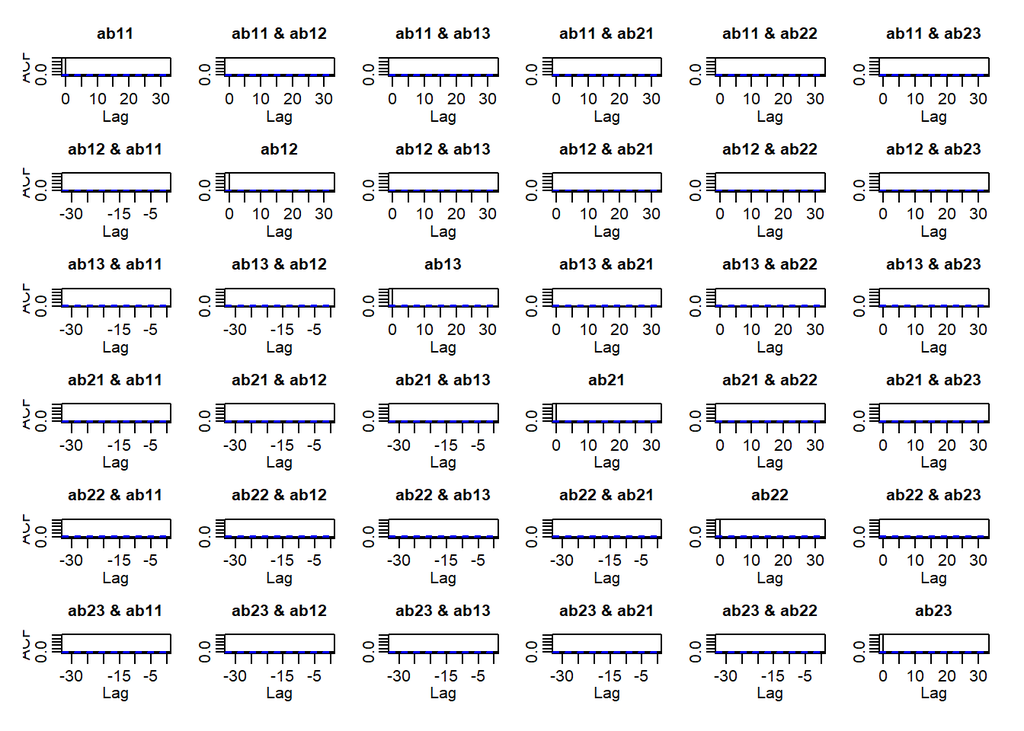

```
##        mu            a             b             ab_vec
## acf    Numeric,41    Numeric,148   Numeric,324   Numeric,1188
## type   "correlation" "correlation" "correlation" "correlation"
## n.used 10000         10000         10000         10000
## lag    Numeric,41    Numeric,148   Numeric,324   Numeric,1188
## series "X[[i]]"      "X[[i]]"      "X[[i]]"      "X[[i]]"
## snames NULL          Character,2   Character,3   Character,6
```

```r
sapply(sample_Q3[c("mu","a","b","ab_vec")],acf)
```

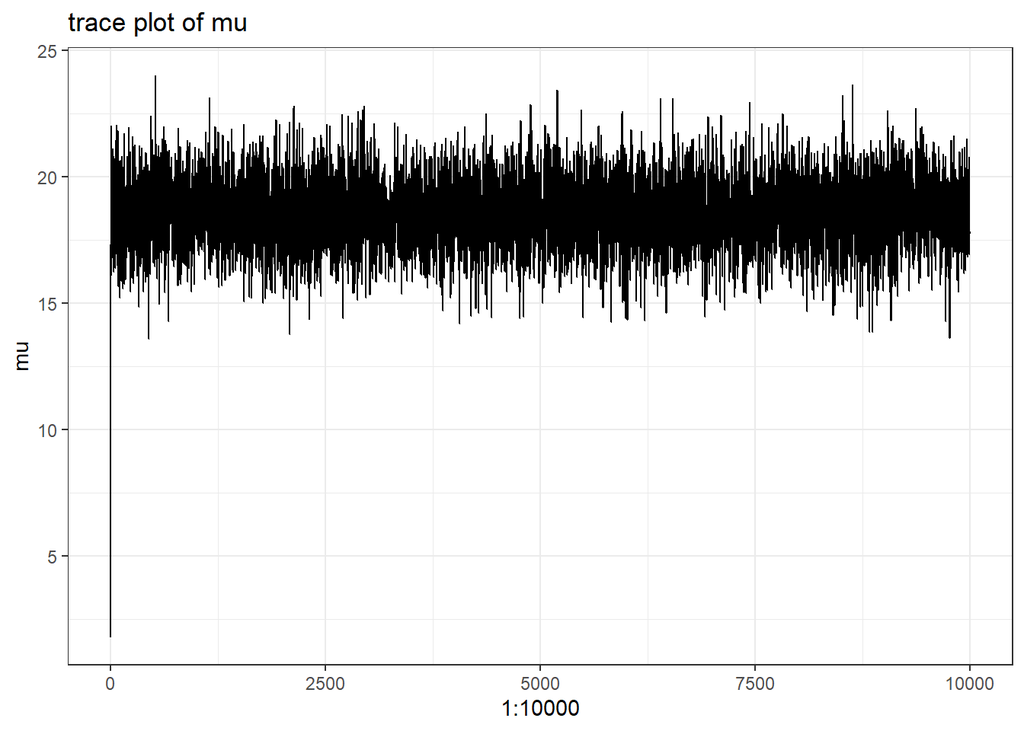

```r
mu <- as.data.frame(sample_Q3$mu) %>%
  `colnames<-`("mu")
a <- as.data.frame(sample_Q3$a)
b <- as.data.frame(sample_Q3$b)
ab <- as.data.frame(sample_Q3$ab_vec)

ggplot(data = mu ,aes(x = 1:10000,y = mu)) +
  geom_line() +
  labs(title = "trace plot of mu")
```

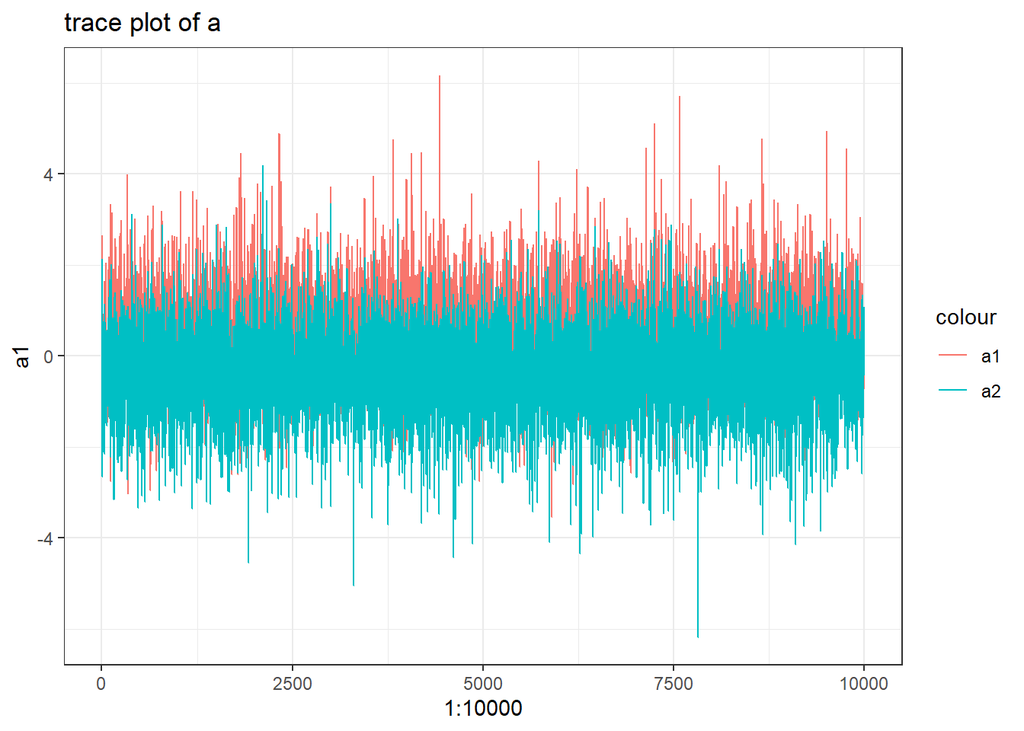

```r
ggplot(data = a, mapping = aes(x=1:10000)) +
  geom_line(aes(y=a1, col = "a1")) +
  geom_line(aes(y=a2, col = "a2")) +
  labs(title = "trace plot of a")
```

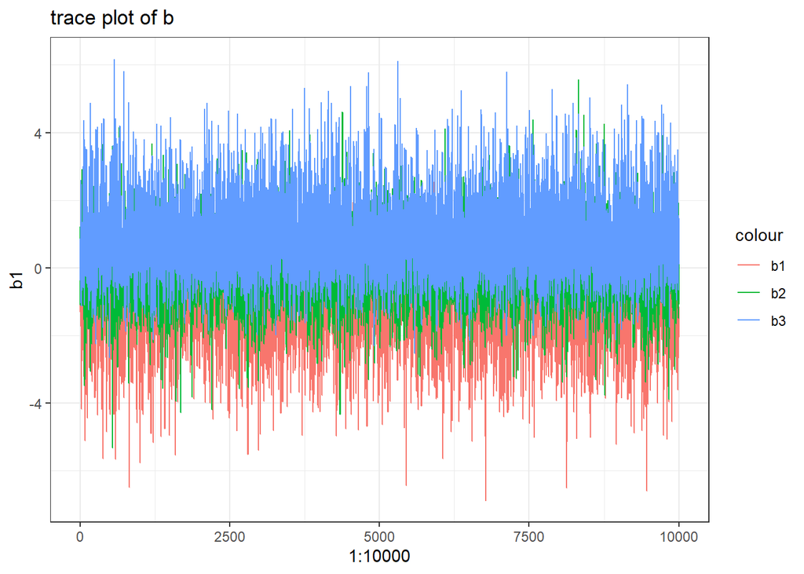

```r
ggplot(data = b, mapping = aes(x=1:10000)) +
  geom_line(aes(y=b1, col = "b1")) +
  geom_line(aes(y=b2, col = "b2")) +
  geom_line(aes(y=b3, col = "b3")) +
  labs(title = "trace plot of b")
```

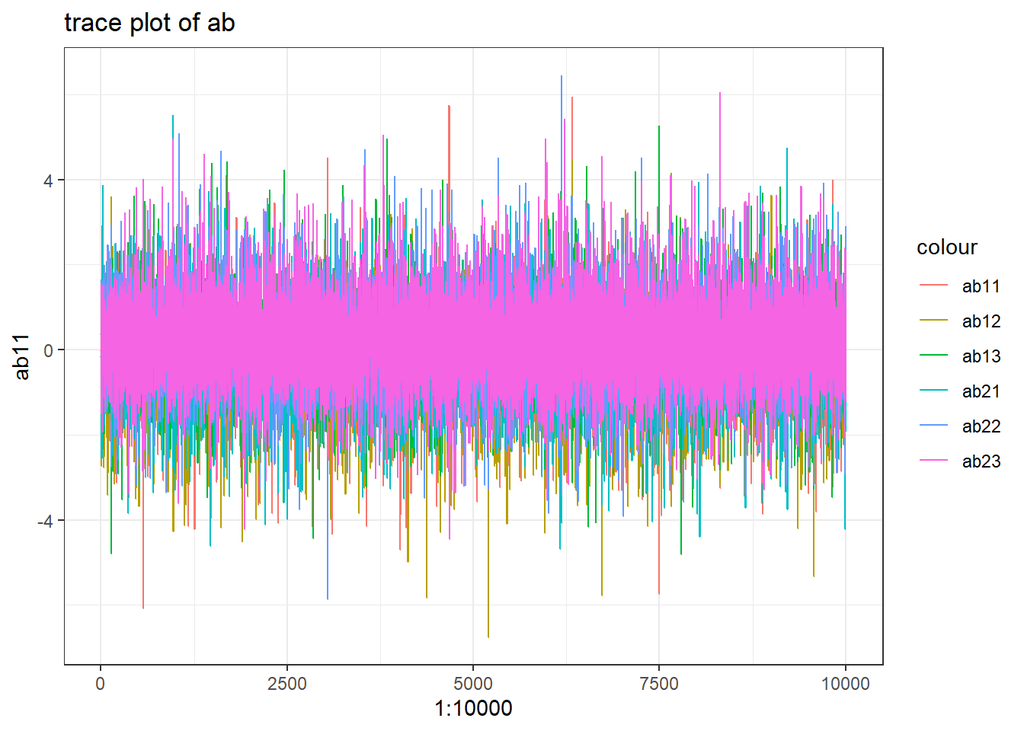

```r
ggplot(data = ab, mapping = aes(x=1:10000)) +
  geom_line(aes(y=ab11, col = "ab11")) +
  geom_line(aes(y=ab12, col = "ab12")) +
  geom_line(aes(y=ab13, col = "ab13")) +
  geom_line(aes(y=ab21, col = "ab21")) +
  geom_line(aes(y=ab22, col = "ab22")) +
  geom_line(aes(y=ab23, col = "ab23")) +
  labs(title = "trace plot of ab")
```

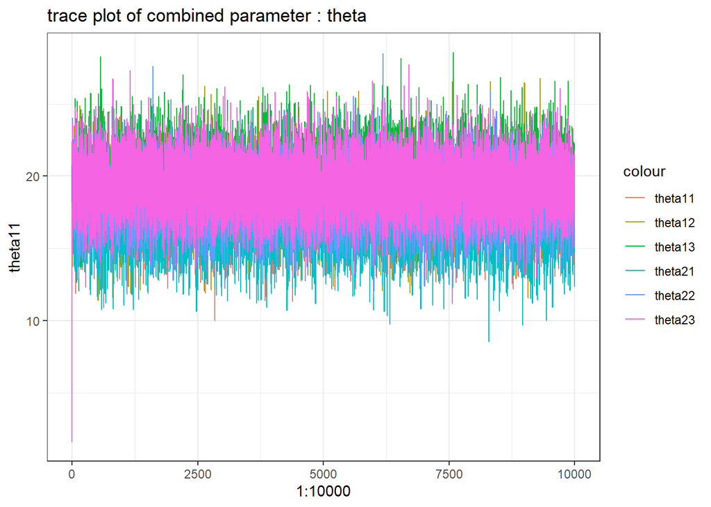

```r
theta.mcmc <- data.frame(theta11 = mu + a$a1 + b$b1 + ab$ab11,
                         theta12 = mu + a$a1 + b$b2 + ab$ab12,
                         theta13 = mu + a$a1 + b$b3 + ab$ab13,
                         theta21 = mu + a$a2 + b$b1 + ab$ab21,
                         theta22 = mu + a$a2 + b$b2 + ab$ab22,
                         theta23 = mu + a$a2 + b$b3 + ab$ab23) %>%
  `colnames<-`(c("theta11","theta12","theta13","theta21","theta22","theta23"))

ggplot(data = theta.mcmc, aes(x= 1:10000)) +
  geom_line(aes(y=theta11, col = "theta11")) +
  geom_line(aes(y=theta12, col = "theta12")) +
  geom_line(aes(y=theta13, col = "theta13")) +
  geom_line(aes(y=theta21, col = "theta21")) +
  geom_line(aes(y=theta22, col = "theta22")) +
  geom_line(aes(y=theta23, col = "theta23")) +
  labs(title = "trace plot of combined parameter : theta")
```

```r
post.mean = list(mu = mean(sample_Q3$mu),
  a = apply(sample_Q3$a,2,mean),
  b = apply(sample_Q3$b,2,mean),
  ab = apply(sample_Q3$ab_vec,2,mean))

theta <- rep(post.mean$mu,6) + rep(post.mean$a,c(3,3)) + rep(post.mean$b,2) + post.mean$ab

names(theta) <- paste(expression(theta),c(11,12,13,21,22,23))
ybar <- ToothGrowth %>%
  group_by(supp,dose) %>%
  dplyr::summarise(ybar = mean(len))

kable(cbind.data.frame(ybar$ybar, theta) %>%
  `colnames<-`(c("sample mean","posterior mean")))
```

|  | sample mean | posterior mean |
| --- | --- | --- |
| theta 11 | 13.23 | 17.89527 |
| theta 12 | 22.70 | 18.87305 |
| theta 13 | 26.06 | 20.06586 |
| theta 21 | 7.98 | 17.18797 |
| theta 22 | 16.77 | 18.56811 |
| theta 23 | 26.14 | 19.39137 |

```r
post.mean
```

```
## $mu
## [1] 18.595
##
## $a
##         a1         a2
##  0.4291910 -0.3546604
##
## $b
##         b1         b2         b3
## -1.0029598  0.1418774  0.9303819
##
## $ab
##        ab11        ab12        ab13        ab21        ab22        ab23
## -0.12596557 -0.29302240  0.11127985 -0.04941064  0.18589240  0.22064343
```